# Lab 03 - Regressione multipla: bontà di adattamento del modello

# Dataset

Usiamo i dati di automobili visti nel lab precedente: leggiamo direttamente i dati usando il file in Moodle:

```r
autompg <- read.csv(file = "../data/autompg.csv")
```

Abbiamo 7 variabili: una variabile risposta (`mpg`) e 6 predittori:

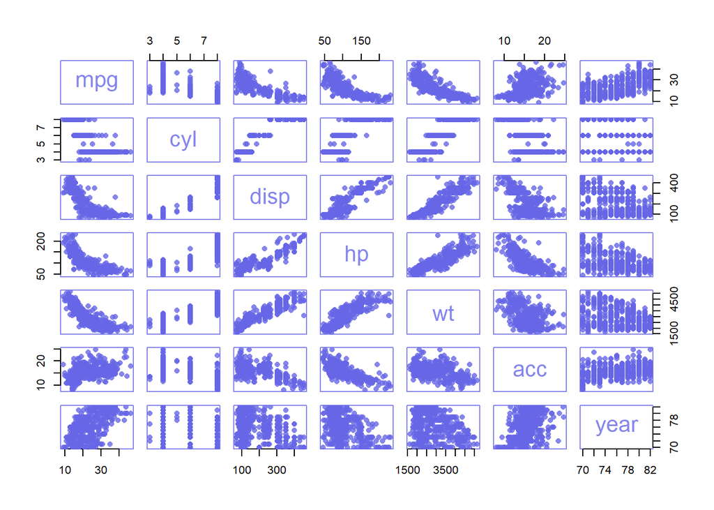

```r
## use rgb to define proportion of reg-green-blue in a color
## extra 4th argument is alpha - the transparency of the points
par(col= rgb(0.4,0.4,0.9,0.8),pch=16)
plot(autompg)
```

Presi individualmente alcuni predittori sembrano essere più o meno correlati con la variabile risposta (`mpg`):

```r
signif(cor(autompg),3)
```

```
##         mpg    cyl   disp     hp     wt    acc   year
## mpg   1.000 -0.777 -0.805 -0.778 -0.832  0.426  0.579
## cyl  -0.777  1.000  0.951  0.843  0.897 -0.508 -0.342
## disp -0.805  0.951  1.000  0.897  0.933 -0.546 -0.368
## hp   -0.778  0.843  0.897  1.000  0.864 -0.692 -0.415
## wt   -0.832  0.897  0.933  0.864  1.000 -0.419 -0.306
## acc   0.426 -0.508 -0.546 -0.692 -0.419  1.000  0.295
## year  0.579 -0.342 -0.368 -0.415 -0.306  0.295  1.000
```

Dovremo individuare un sottoinsieme di predittori utili a costruire un modello predittivo per `mpg` (vediamo inoltre che i predittori sono anche correlati tra loro).

# Specificazione del modello

Specifichiamo un modello con due predittori `hp` e `year`:

$$Y_i = \beta_0 + \beta_{hp} \text{hp}_{i} + \beta_{year} \text{year}_{i}
+ \varepsilon_i, \qquad i = 1, 2, \ldots, n$$
con $\varepsilon_i \sim \mathcal{N}(0, \sigma^2)$ (errori indipendenti, identicamente distribuiti e omoschedastici).

```r
fit1 <- lm(mpg~hp+year, data = autompg)
summary(fit1)
```

```
##
## Call:
## lm(formula = mpg ~ hp + year, data = autompg)
##
## Residuals:
##      Min       1Q   Median       3Q      Max
## -12.0794  -3.0980  -0.4271   2.6023  15.3045
##
## Coefficients:
##               Estimate Std. Error t value Pr(>|t|)
## (Intercept) -12.859591   5.379128  -2.391   0.0173 *
## hp           -0.131650   0.006356 -20.714   <2e-16 ***
## year          0.658903   0.066680   9.882   <2e-16 ***
## ---
## Signif. codes:  0 '***' 0.001 '**' 0.01 '*' 0.05 '.' 0.1 ' ' 1
##
## Residual standard error: 4.398 on 387 degrees of freedom
## Multiple R-squared:  0.685,  Adjusted R-squared:  0.6833
## F-statistic: 420.7 on 2 and 387 DF,  p-value: < 2.2e-16
```

Per i singoli parametri $\beta_j$ vediamo nel `summary` la significatività per il test $H_0: \beta_j = 0$. Ma questo ci dice quanto è significativo ogni singolo $\beta_j$ quando anche le altre variabili sono incluse nel modello. Cosa possiamo dire della significatività del modello intero? Il modello è in grado di spiegare una parte rilevante della variabilità di $Y$ o non si comporta poi in maniera diversa da un modello in cui la stima per ogni $Y|X$ è sempre lo stesso scalare?

Formalizziamo questa domanda con un sistema di verifica di ipotesi:
$$H_0: \beta_{hp} = \beta_{year} = 0 \quad
VS \quad H_1: \text{ any of } \beta_{hp} \text{ or } \beta_{year} \neq 0$$

Sotto l’ipotesi nulla il modello si riduce a
$$Y_i = \beta_0 + \varepsilon_i, \qquad i = 1, 2, \ldots, n$$
un modello con un solo parametro (i.e. un modello in cui la stima per ogni $Y|X$ è uno scalare).

Per confrontare i due modelli confrontiamo i residui ottenuti sotto i due modelli e si può mostrare che si può costruire una statistica test così definita:

$$F = \frac{\sum_{i=1}^{n}(\hat{Y}_{A,i} - \bar{Y})^2 / (p -
1)}{\sum_{i=1}^{n}(Y_i - \hat{Y}_{A,i})^2 / (n - p)},$$

questa va poi confrontata con una distribuzione $F_{p-1, n-p}$. Il tutto viene spesso presentato in una tavola `anova`:

```r
fit_null <- lm(mpg ~ 1, data = autompg)
anova(fit_null,fit1)
```

```
## Analysis of Variance Table
##
## Model 1: mpg ~ 1
## Model 2: mpg ~ hp + year
##   Res.Df     RSS Df Sum of Sq      F    Pr(>F)
## 1    389 23761.7
## 2    387  7485.8  2     16276 420.71 < 2.2e-16 ***
## ---
## Signif. codes:  0 '***' 0.001 '**' 0.01 '*' 0.05 '.' 0.1 ' ' 1
```

Vediamo da dove vengono i vari numeri. Partiamo dalle somme dei quadrati dei residui:

```r
### SS under null
sum(fit_null$residuals^2); sum((autompg$mpg - mean(autompg$mpg))^2)
```

```
## [1] 23761.67
```

```
## [1] 23761.67
```

```r
## SS under alternative
sum(fit1$residuals^2)
```

```
## [1] 7485.791
```

```r
## difference in Sum of Squares
sum(fit_null$residuals^2) - sum(fit1$residuals^2)
```

```
## [1] 16275.88
```

```r
## this is equivalent to
sum((fit_null$fitted.values - fit1$fitted.values)^2)
```

```
## [1] 16275.88
```

```r
### to compute the F:
# scale each Sum of Squares by the appropriate number of degrees of freedom
```

Quanti gradi di libertà sono collegati ad ognuno dei componenti delle somme dei quadrati?

```r
## null model
fit_null$df.residual
```

```
## [1] 389
```

```r
## larger model (alternative)
fit1$df.residual
```

```
## [1] 387
```

```r
## their difference
fit_null$df.residual - fit1$df.residual
```

```
## [1] 2
```

Scaliamo ognuno dei componenti della somma dei quadrati per il corretto numero di gradi di libertà:

```r
## Alternative model
sum(fit1$residuals^2)/fit1$df.residual
```

```
## [1] 19.34313
```

```r
## difference in Sum of Squares
(sum(fit_null$residuals^2) - sum(fit1$residuals^2))/(fit_null$df.residual - fit1$df.residual)
```

```
## [1] 8137.94
```

La statistica test quindi è:

```r
num <- (sum(fit_null$residuals^2) - sum(fit1$residuals^2))/(fit_null$df.residual - fit1$df.residual)
den <- sum(fit1$residuals^2)/fit1$df.residual
(Fstat <- num/den)
```

```
## [1] 420.7148
```

Per valutare la significatività del test possiamo calcolare il p-value usando `pf` o controllare se $F_{obs}$ è grande rispetto ad una distribuzione F con 2 e 387 gradi di libertà:

```r
## p-value
pf(Fstat, df1 = fit_null$df.residual-fit1$df.residual,
   df2 = fit1$df.residual, lower.tail = FALSE)
```

```
## [1] 8.566348e-98
```

```r
### very small p-value
# same as (except for numerical issues)
1 - pf(Fstat, df1 = fit_null$df.residual-fit1$df.residual,
       df2 = fit1$df.residual)
```

```
## [1] 0
```

```r
## Find the rejection region for the 1% significance test
qf(0.99,  df1 = fit_null$df.residual-fit1$df.residual,
   df2 = fit1$df.residual)
```

```
## [1] 4.660407
```

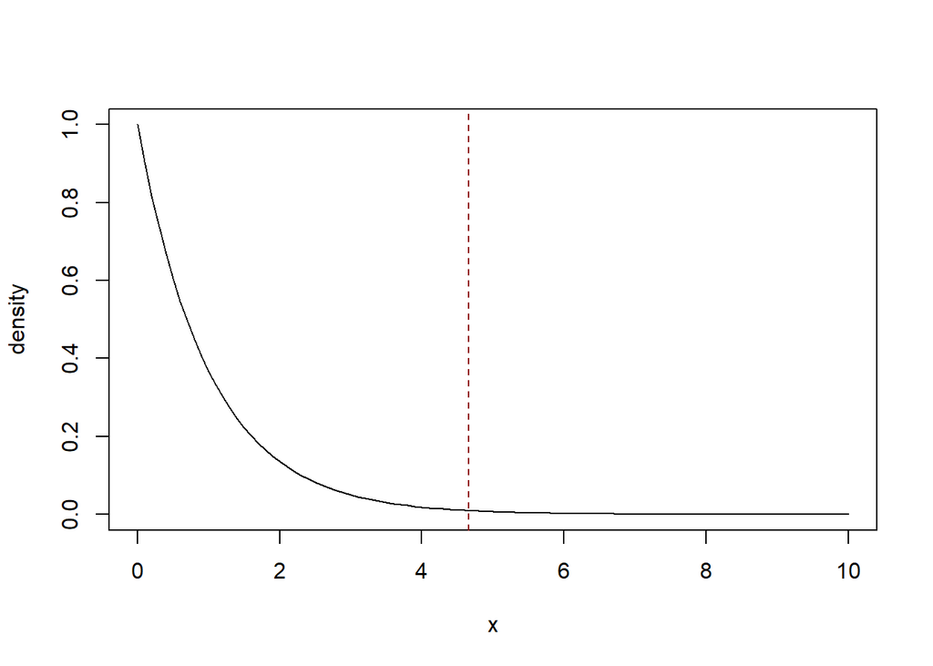

```r
### reject H_0 at 1% if Fstat > 4.666
## definitely reject
# what does the distribution looks like?
curve(df(x, df1 = fit_null$df.residual-fit1$df.residual,
   df2 = fit1$df.residual), from = 0, to = 10, ylab = "density")
# the rejection region at alpha = 1%
abline(v = qf(0.99,  df1 = fit_null$df.residual-fit1$df.residual,
   df2 = fit1$df.residual), col = "darkred", lty = 2)
```

Tipicamente non specificheremo il modello `fit_null` ma potremo usare direttamente la statistica stampata nel `summary`:

```r
summary(fit1)$fstatistic
```

```
##    value    numdf    dendf
## 420.7148   2.0000 387.0000
```

dove per altro viene anche stampato il p-value legato alla statistica:

```r
summary(fit1)
```

```
##
## Call:
## lm(formula = mpg ~ hp + year, data = autompg)
##
## Residuals:
##      Min       1Q   Median       3Q      Max
## -12.0794  -3.0980  -0.4271   2.6023  15.3045
##
## Coefficients:
##               Estimate Std. Error t value Pr(>|t|)
## (Intercept) -12.859591   5.379128  -2.391   0.0173 *
## hp           -0.131650   0.006356 -20.714   <2e-16 ***
## year          0.658903   0.066680   9.882   <2e-16 ***
## ---
## Signif. codes:  0 '***' 0.001 '**' 0.01 '*' 0.05 '.' 0.1 ' ' 1
##
## Residual standard error: 4.398 on 387 degrees of freedom
## Multiple R-squared:  0.685,  Adjusted R-squared:  0.6833
## F-statistic: 420.7 on 2 and 387 DF,  p-value: < 2.2e-16
```

Il test `anova` è un test generale che può essere usato per confrontare qualunque modello annidato, per esempio potremmo pensare di confrontare un modello molto complesso in cui inseriamo tutti i predittori e un modello con due soli predittori: per esempio `wt` e `year`.

```r
fit_base <- lm(mpg~wt+year, data = autompg)
fit_all <- lm(mpg~.,data = autompg)
### using the . (dot) is a shortcut to say: include everything
fit_all <- lm(mpg~cyl+disp+hp+wt+acc+year,data = autompg)
summary(fit_all)
```

```
##
## Call:
## lm(formula = mpg ~ cyl + disp + hp + wt + acc + year, data = autompg)
##
## Residuals:
##     Min      1Q  Median      3Q     Max
## -8.7162 -2.3918 -0.0473  2.0381 14.3386
##
## Coefficients:
##               Estimate Std. Error t value Pr(>|t|)
## (Intercept) -1.470e+01  4.772e+00  -3.081  0.00221 **
## cyl         -3.534e-01  3.335e-01  -1.060  0.28993
## disp         8.028e-03  7.376e-03   1.088  0.27709
## hp          -6.625e-04  1.387e-02  -0.048  0.96193
## wt          -6.791e-03  6.709e-04 -10.121  < 2e-16 ***
## acc          8.053e-02  1.026e-01   0.785  0.43297
## year         7.577e-01  5.289e-02  14.328  < 2e-16 ***
## ---
## Signif. codes:  0 '***' 0.001 '**' 0.01 '*' 0.05 '.' 0.1 ' ' 1
##
## Residual standard error: 3.439 on 383 degrees of freedom
## Multiple R-squared:  0.8093, Adjusted R-squared:  0.8064
## F-statistic:   271 on 6 and 383 DF,  p-value: < 2.2e-16
```

Vediamo che il modello `fit_all` è molto significativo: è un modello che cattura più variabilità di un modello in cui si una un unico parametro. La domanda è ora se questo modello complesso che usa 7 parametri cattura molta più variabilità del modello più semplice in cui usiamo solo due variabili `wt` e `year`. è veramente necessario avere un modello così più complesso o l’aggiunta di parametri non mi porta ad un vantaggio considerevole? Se usassimo il valori di MSE e $R^2$ per giudicare la bontà di adattamento di un modello penseremmo che il modello complesso sia migliore:

```r
## rsquare and mse for two models
summary(fit_base)$r.square; sum(fit_base$residuals^2)
```

```
## [1] 0.8082355
```

```
## [1] 4556.646
```

```r
summary(fit_all)$r.square; sum(fit_all$residuals^2)
```

```
## [1] 0.8093372
```

```
## [1] 4530.466
```

ma guardiamo ad esempio a cosa succede agli intervalli di confidenza della media:

```r
nd <- data.frame(apply(autompg,2,quantile,c(0.01,0.5,0.9)))
(ci_all <- predict(fit_all,newdata = nd,interval = "conf"))
```

```
##          fit      lwr      upr
## 1%  26.23013 24.19137 28.26888
## 50% 24.77921 24.06877 25.48964
## 90% 19.01879 17.50895 20.52863
```

```r
(ci_base <- predict(fit_base,newdata = nd,interval = "conf"))
```

```
##          fit      lwr      upr
## 1%  26.90635 25.95849 27.85421
## 50% 24.57827 24.22949 24.92705
## 90% 18.64130 17.73176 19.55084
```

```r
ci_all[,3]-ci_all[,2]
```

```
##       1%      50%      90%
## 4.077509 1.420871 3.019683
```

```r
ci_base[,3]-ci_base[,2]
```

```
##        1%       50%       90%
## 1.8957202 0.6975514 1.8190836
```

```r
# (ci_null <- predict(fit_null,newdata = nd,interval = "conf"))
```

Quando usiamo troppi parametri facciamo aumentare l’incertezza nella stima: stiamo inserendo troppe variabili che non spiegano variabilità generale dei dati ma seguono caratteristiche di alcune osservazioni. Dobbiamo bilanciare la necessità di “spiegare bene” i dati con la capacità del modello di fare predizioni non troppo incerte: per ottenere questo bilanciamento cerchiamo di specificare modelli **parsimoniosi**.

Per verificare se la parte di variabilità catturata dal modello più complesso è decisamente più grande di quella catturata dal modello più semplice utilizziamo una verifica di ipotesi in cui formalizziamo in confronto tra i due modelli notando che il modello `fit_base` è annidato in `fit_all` e che può quindi essere derivato da `fit_all` quando $\beta_{cyl} = \beta_{disp} = \beta_{hp}= \beta_{acc} = 0$. Costruiamo quindi un test per il seguente sistema di verifica di ipotesi:
$$H_0: \beta_{cyl} = \beta_{disp} = \beta_{hp}=
\beta_{acc} = 0$$
a cui contrastiamo
$$H_1: \text{ any of } \beta_{cyl} \text{ or }
\beta_{disp} \text{ or } \beta_{hp} \text{ or } \beta_{acc} \neq
0$$

Usiamo quindi il test ANOVA

```r
anova(fit_base,fit_all)
```

```
## Analysis of Variance Table
##
## Model 1: mpg ~ wt + year
## Model 2: mpg ~ cyl + disp + hp + wt + acc + year
##   Res.Df    RSS Df Sum of Sq      F Pr(>F)
## 1    387 4556.6
## 2    383 4530.5  4     26.18 0.5533 0.6967
```

Da dove vengono i numeri nella tabella?

```r
## sumsq under null
sum(residuals(fit_base)^2)
```

```
## [1] 4556.646
```

```r
## sumsq under alternative
sum(residuals(fit_all)^2)
```

```
## [1] 4530.466
```

```r
### their difference
sum(residuals(fit_base)^2) - sum(residuals(fit_all)^2)
```

```
## [1] 26.17981
```

```r
# equivalent to
sum((fitted(fit_base) - fitted(fit_all))^2)
```

```
## [1] 26.17981
```

Vediamo che la differenza tra le somme dei residui/i valori stimati al quadrato non è così grande: ma come dire se un valore è effettivamente piccolo o grande? Standardizziamo i valori per i giusti gradi di libertà e deriviamo $F_{obs}$

```r
## df of the null
fit_base$df.residual
```

```
## [1] 387
```

```r
## df of the alternative
fit_all$df.residual
```

```
## [1] 383
```

```r
### their difference
fit_base$df.residual - fit_all$df.residual
```

```
## [1] 4
```

La statistica F-osservata

```r
dfnum <- fit_base$df.residual-fit_all$df.residual
dfden <- fit_all$df.residual
num <- (sum(fit_base$residuals^2) - sum(fit_all$residuals^2))/dfnum
den <- sum(fit_all$residuals^2)/dfden
(Fstat <- num/den)
```

```
## [1] 0.5533023
```

```r
## p-value
pf(Fstat, df1 = dfnum, df2 = dfden, lower.tail = FALSE)
```

```
## [1] 0.6967249
```

```r
### very small p-value
## Find the rejection region for the 10% significance test
qf(0.9, df1 = dfnum, df2 = dfden)
```

```
## [1] 1.959593
```

```r
### reject H_0 at 10% if Fstat > 1.96
## definitely can not reject
```

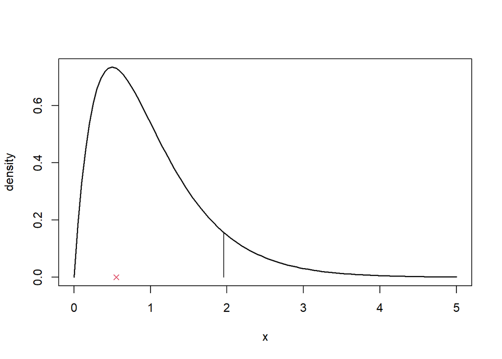

```r
curve(df(x, df1 = dfnum, df2 = dfden),from=0,to=5, ylab="density", lwd = 1.5)
reg_cutoff <- qf(0.9, df1 = dfnum, df2 = dfden)
segments(x0 = reg_cutoff, y0=0,y1=df(reg_cutoff, df1 = dfnum, df2 = dfden))
points(Fstat, 0, col=2, pch=4)
```

```r
### Fstat is within the non-rejection region
```

Non possiamo rifiutare l’ipotesi nulla che i quattro parametri del modello siamo pari a zero: sotto questo modello più semplice otteniamo una somma dei quadrati dei residui che è comparabile a quella ottenuta con il modello più complesso `fit_all`. Decidiamo quindi che sia più conveniente tenere il modello `fit_base` come modello da usare per fare predizione dato che questo è parsimonioso.

# Bontà di adattamento

L’approccio ANOVA può essere usato per confrontare con un test formale modelli annidati, cioè modelli in cui il modello più parsimonioso può essere derivato ponendo uno o più dei parametri $\beta_j$ del modello pari a 0. Spesso però ci troviamo a voler confrontare modelli che non siano annidati: come si può fare? Possiamo usare usare dei criteri di bontà di adattamento quali l’adjusted $R^2$ e i criteri di informazione come AIC and BIC.

## Adjusted $R^2$

Abbiamo definito il coefficiente di determinazione $R^2$ come segue
$$R^2 =
1-\frac{SS_{res}}{SS_{tot}}$$

```r
summary(fit_base)$r.square
```

```
## [1] 0.8082355
```

```r
## derived as
1- sum(fit_base$residuals^2)/sum(fit_null$residuals^2)
```

```
## [1] 0.8082355
```

ma questo coefficiente aumenta sempre quando si aggiungono predittori al modello (il valore di $R^2$ per il modello `fit_all` è 0.8093372). Per constatare questa caratteristica utilizziamo il valore *adjusted* $R^2$ - che penalizza modelli molto complessi:
$$R_{Adj}^2 =
1-\frac{SS_{res}/(n-p-1)}{SS_{tot}/(n-1)}$$

```r
##  add useless variables and R2 increases!
## set.seed(134); fit_useless <- lm(autompg$mpg~cbind(autompg$wt,autompg$year,matrix(rnorm(390*40),ncol=40)))
## summary(fit_useless)$r.square
## summary(fit_useless)$adj.r.square
summary(fit_base)$adj.r.square
```

```
## [1] 0.8072444
```

```r
1- (sum(fit_base$residuals^2)/(fit_base$df.residual))/(sum(fit_null$residuals^2)/fit_null$df.residual)
```

```
## [1] 0.8072444
```

```r
summary(fit_all)$adj.r.square
```

```
## [1] 0.8063504
```

Il valore di adjusted $R^2$ è più piccolo per il modello più complesso: sebbene il valore di $R^2$ aumenti per il modello più complesso, questo incremento è mitigato quando si tiene in considerazione la complessità del modello.

## Criteri di informazione

Un altro approccio utile a misurare la bontà di adattamento dei modelli in cui si tiene conto della complessità del modello sono i criteri di informazione legati alla verosimiglianza:
$$IC = -2*logLik(M) + k * p(M)$$

Quando $k=2$ si ha AIC, quando $k=log(n)$ si ha BIC (quindi quando $n$ e grande BIC penalizza di più).

R permette di derivare la verosimiglianza dei modelli stimati:

```r
logLik(fit_base)
```

```
## 'log Lik.' -1032.734 (df=4)
```

```r
## can be directly calculated as
sum(dnorm(autompg$mpg, fit_base$fitted.values, summary(fit_base)$sigma,log = TRUE))
```

```
## [1] -1032.74
```

da cui è possibile derivare i criteri (esistono poi funzioni specifiche)

```r
## AIC
- 2*as.numeric(logLik(fit_base)) + 2 * (1+length(fit_base$coef))
```

```
## [1] 2073.468
```

```r
AIC(fit_base)
```

```
## [1] 2073.468
```

```r
- 2*as.numeric(logLik(fit_all)) + 2 * (1+length(fit_all$coef))
```

```
## [1] 2079.221
```

```r
AIC(fit_all)
```

```
## [1] 2079.221
```

```r
### one can fit many models and then compare them
AIC(fit_null,fit1,fit_base,fit_all)
```

```
##          df      AIC
## fit_null  2 2713.548
## fit1      4 2267.072
## fit_base  4 2073.468
## fit_all   8 2079.221
```

```r
which.min(AIC(fit_null,fit1,fit_base,fit_all)$AIC)
```

```
## [1] 3
```

```r
## BIC
n <- nrow(autompg)
- 2*as.numeric(logLik(fit_base)) + log(n) * (1+length(fit_base$coef))
```

```
## [1] 2089.333
```

```r
BIC(fit_base)
```

```
## [1] 2089.333
```

```r
- 2*as.numeric(logLik(fit_all)) + log(n)  * (1+length(fit_all$coef))
```

```
## [1] 2110.95
```

```r
BIC(fit_all)
```

```
## [1] 2110.95
```

```r
BIC(fit_null,fit1,fit_base,fit_all)
```

```
##          df      BIC
## fit_null  2 2721.480
## fit1      4 2282.937
## fit_base  4 2089.333
## fit_all   8 2110.950
```

```r
which.min(BIC(fit_null,fit1,fit_base,fit_all)$BIC)
```

```
## [1] 3
```

Sia AIC che BIC indicano che `fit_base` sia il modello preferibile.

Questi criteri possono essere utilizzati per scegliere quali variabili inserire in un modello predittivo.

# Verifica della teoria tramite simulazione

Nelle slide vengono presentati i seguenti risultati:

$$\text{E}[\hat{\beta}_j] = \beta_j.
\quad \text{ and } \quad
\text{Var}[\hat{\beta}] = \sigma^2 \left( X^\top X \right)^{-1}$$

Vediamo se questi sono validi (quando il modello è specificato correttamente). Prendiamo `fit_base` come ispirazione e creiamo un modello *vero* da cui possiamo generare dati:

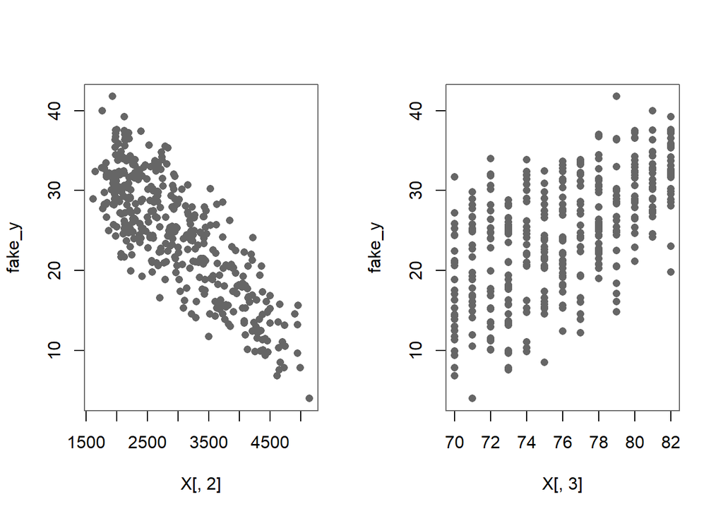

```r
X <- model.matrix(fit_base); beta_true <- c(-14.6,-0.006,0.75)
colnames(X) <- c("Int","x1","x2")
sigma_true <- 3.4; n <- nrow(X)
set.seed(374)
fake_y <- X %*% beta_true + rnorm(n,0,sigma_true)
fake_auto <- data.frame(y = fake_y, X[,-1])
par(mfrow=c(1,2),pch=16,col="grey40")
plot(X[,2],fake_y)
plot(X[,3],fake_y)
```

```r
summary(lm(y~x1+x2,data=fake_auto))
```

```
##
## Call:
## lm(formula = y ~ x1 + x2, data = fake_auto)
##
## Residuals:
##      Min       1Q   Median       3Q      Max
## -11.7025  -2.2036   0.0178   2.3076  10.2341
##
## Coefficients:
##               Estimate Std. Error t value Pr(>|t|)
## (Intercept) -1.438e+01  3.972e+00   -3.62 0.000333 ***
## x1          -6.071e-03  2.121e-04  -28.62  < 2e-16 ***
## x2           7.499e-01  4.909e-02   15.28  < 2e-16 ***
## ---
## Signif. codes:  0 '***' 0.001 '**' 0.01 '*' 0.05 '.' 0.1 ' ' 1
##
## Residual standard error: 3.387 on 387 degrees of freedom
## Multiple R-squared:  0.7902, Adjusted R-squared:  0.7891
## F-statistic: 728.7 on 2 and 387 DF,  p-value: < 2.2e-16
```

```r
## results are in line with true values
```

Ripetiamo questo esperimento più volte:

```r
generate_and_estimate <- function(X,trueBetas,trueSigma){
  fake_y <- X %*% trueBetas + rnorm(n,0,trueSigma)
  fake_data <- data.frame(y = fake_y, X[,-1])
  fake_fit <- lm(y~.,data=fake_data)
  fake_fit$coef
}
generate_and_estimate(X=X,trueBetas = beta_true,trueSigma = sigma_true)
```

```
##   (Intercept)            x1            x2
## -15.755520352  -0.005895323   0.760485722
```

```r
NSIM = 500; set.seed(40366)
out_sim <- t(replicate(n = NSIM,generate_and_estimate(X=X,trueBetas = beta_true,trueSigma = sigma_true)))
```

`out_sim` contiene `NSIM` repliche della stima di $\beta$ nel modello: possiamo usare queste ripetizioni per generare la distribuzione campionaria di $\hat{\beta}$.

Gli stimatori sono non-distorti?

```r
colMeans(out_sim)
```

```
##   (Intercept)            x1            x2
## -14.764952473  -0.005985889   0.751656787
```

```r
beta_true
```

```
## [1] -14.600  -0.006   0.750
```

Non male. La teoria dice che la matrice di varianza covarianza degli stimatori è:

```r
sigma_true^2 * solve(t(X) %*% X)
```

```
##               Int            x1            x2
## Int 15.8930811700 -3.792233e-04 -1.939760e-01
## x1  -0.0003792233  4.532063e-08  3.214476e-06
## x2  -0.1939759626  3.214476e-06  2.427733e-03
```

Dalla simulazione deriviamo

```r
cov(out_sim)
```

```
##               (Intercept)            x1            x2
## (Intercept) 17.2442122153 -4.389673e-04 -2.098259e-01
## x1          -0.0004389673  5.079540e-08  3.813058e-06
## x2          -0.2098259455  3.813058e-06  2.616708e-03
```

Non male: se aumentiamo `NSIM` possiamo probabilmente migliorare la precisione della stima.

Possiamo usare le stime dei parametri per valutare l’incertezza nella stima della funzione predittiva:

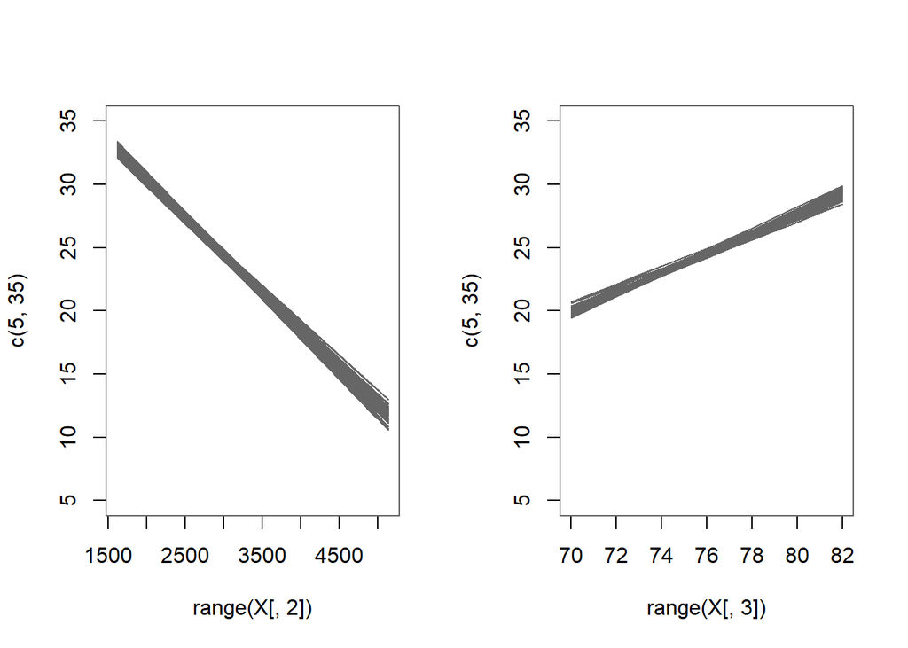

```r
par(mfrow=c(1,2),col="gray40")
### fix x2 to its mean
Xnd <- as.matrix(cbind(rep(1,nrow(X)),X[,2],mean(X[,3])))
plot(range(X[,2]),c(5,35),type ="n")
set.seed(4854)
for(j in sample(seq(1,NSIM), size = 50)) lines(Xnd[,2],Xnd%*%out_sim[j,]) # 50 lines is already enough
### fix x1 to its mean
Xnd <- as.matrix(cbind(rep(1,nrow(X)),mean(X[,2]),X[,3]))
plot(range(X[,3]),c(5,35),type ="n")
for(j in sample(seq(1,NSIM), size = 50))  lines(Xnd[,3],Xnd%*%out_sim[j,])
```

Queste possono essere confrontate con le stime dell’incertezza ottenute tramite le forme specificate nelle slides:

$$SD[\hat{y}(x_0)] = \sigma
\sqrt{x_{0}^\top\left(X^\top X\right)^{-1}x_{0}}$$

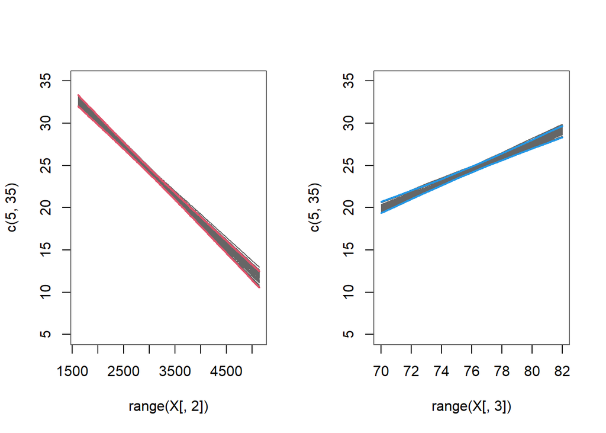

```r
par(mfrow=c(1,2),col="gray40")
### fix x2 to its mean
Xnd <- as.matrix(cbind(rep(1,nrow(X)),sort(X[,2]),mean(X[,3])))
plot(range(X[,2]),c(5,35),type ="n")
set.seed(4854)
for(j in sample(seq(1,NSIM), size = 50)) lines(Xnd[,2],Xnd%*%out_sim[j,]) # 50 lines is already enough
lines(Xnd[,2],Xnd %*% beta_true + qnorm(0.975) * sigma_true * sqrt(diag(Xnd %*% solve(t(X) %*% X) %*% t(Xnd))), col = 2, lwd = 2)
lines(Xnd[,2],Xnd %*% beta_true + qnorm(0.025) * sigma_true * sqrt(diag(Xnd %*% solve(t(X) %*% X) %*% t(Xnd))), col = 2, lwd = 2)
### fix x1 to its mean
Xnd <- as.matrix(cbind(rep(1,nrow(X)),mean(X[,2]),sort(X[,3])))
plot(range(X[,3]),c(5,35),type ="n")
for(j in sample(seq(1,NSIM), size = 50))  lines(Xnd[,3],Xnd%*%out_sim[j,])
lines(Xnd[,3],Xnd %*% beta_true + qnorm(0.975) * sigma_true * sqrt(diag(Xnd %*% solve(t(X) %*% X) %*% t(Xnd))), col = 4, lwd = 2)
lines(Xnd[,3],Xnd %*% beta_true + qnorm(0.025) * sigma_true * sqrt(diag(Xnd %*% solve(t(X) %*% X) %*% t(Xnd))), col = 4, lwd = 2)
```

La predizione di $E[Y|X]$ è abbastanza precisa, c’è poca variabilità nella stima. Guardiamo ora cosa succede se uno dei predittori ha poco effetto, prendiamo ad esempio la variabile `cyl` e assumiamo che non abbia quasi alcun effetto:

```r
NSIM = 500; set.seed(554)
X2 <- cbind(X, x3 = autompg$cyl)
beta_true2 <-  c(beta_true,-0.05)
added_out_sim <- t(
  replicate(n = NSIM,
            generate_and_estimate(X= X2, trueBetas = beta_true2,
                                  trueSigma = sigma_true)))
cov(added_out_sim); sigma_true^2 * solve(t(X2) %*% X2) # ok
```

```
##               (Intercept)            x1            x2            x3
## (Intercept) 16.5414884144 -1.488798e-04 -2.015427e-01 -1.407517e-01
## x1          -0.0001488798  2.160036e-07  3.744912e-07 -9.535824e-05
## x2          -0.2015427296  3.744912e-07  2.523566e-03  1.634096e-03
## x3          -0.1407516580 -9.535824e-05  1.634096e-03  5.464942e-02
```

```
##               Int            x1            x2            x3
## Int 16.3303490819 -1.101671e-04 -1.992314e-01 -1.532955e-01
## x1  -0.0001101671  2.108742e-07 -1.925446e-08 -9.432458e-05
## x2  -0.1992313931 -1.925446e-08  2.490897e-03  1.842426e-03
## x3  -0.1532954841 -9.432458e-05  1.842426e-03  5.374166e-02
```

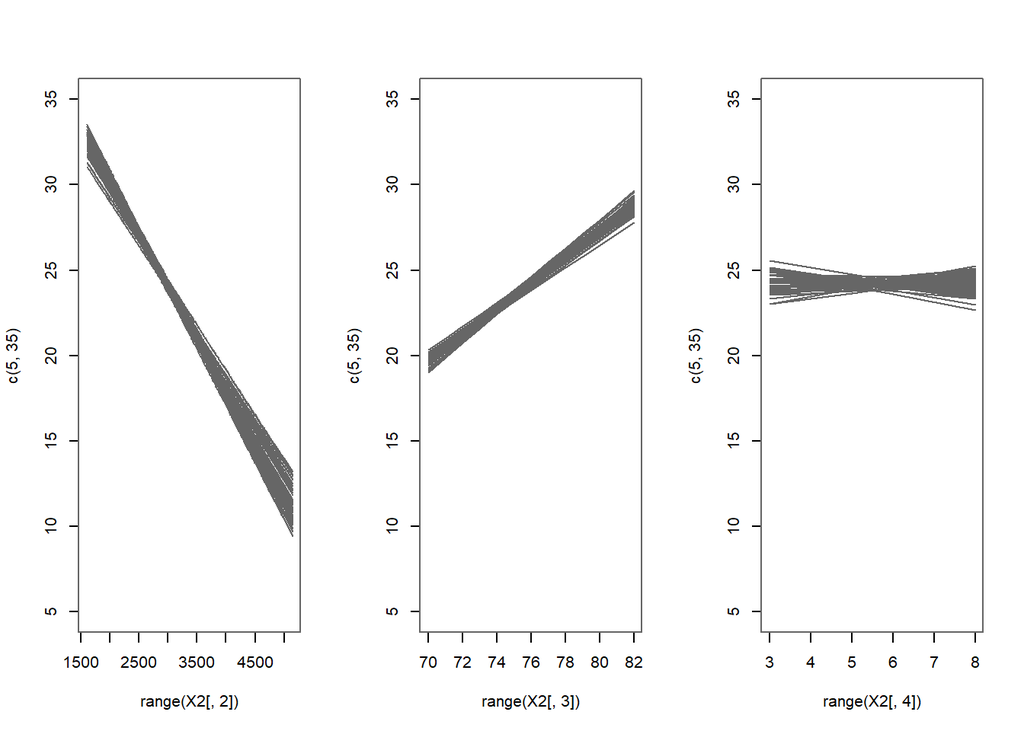

```r
### fix year and cyl to their mean
par(mfrow=c(1,3),col="gray40")
### fix x2 to its mean
Xnd <- as.matrix(cbind(rep(1,nrow(X2)),sort(X2[,2]),mean(X2[,3]),mean(X2[,4])))
## rgb takes red - green - blue proportions; the fourth parameter is a transparency parameter
plot(range(X2[,2]),c(5,35),type ="n")
set.seed(4854)
for(j in sample(seq(1,NSIM), size = 50)) lines(Xnd[,2],Xnd%*%added_out_sim[j,]) # 50 lines is already enough
### fix wt to its mean
Xnd <- as.matrix(cbind(rep(1,nrow(X2)),mean(X2[,2]),sort(X2[,3]),mean(X2[,4])))
## rgb takes red - green - blue proportions; the fourth parameter is a transparency parameter
plot(range(X2[,3]),c(5,35),type ="n")
set.seed(4854)
for(j in sample(seq(1,NSIM), size = 50)) lines(Xnd[,3],Xnd%*%added_out_sim[j,]) # 50 lines is already enough
### fix wt and year to their mean
Xnd <- as.matrix(cbind(rep(1,nrow(X2)),mean(X2[,2]),mean(X2[,3]),sort(X2[,4])))
plot(range(X2[,4]),c(5,35),type ="n")
for(j in sample(seq(1,NSIM), size = 50)) lines(Xnd[,4],Xnd%*%added_out_sim[j,]) # 50 lines is already enough
```

Vediamo che la stima della variabile che ha un effetto nullo (non significativo), va su e giù attorno ad una media formando una forma “piatta”.

Possiamo usare la simulazione per verificare cose succede se alcune delle assunzioni del modello non sono verificate dai dati. Per esempio possiamo vedere cosa succede se gli errori non sono distribuiti normalmente:

```r
generateT_and_estimate <- function(X,trueBetas,trueSigma){
  fake_data <- data.frame(X[,-1])
  nobs <- nrow(X)
  fake_data$y <- X %*% trueBetas + trueSigma * rt(n,df=3) # t-distributed errors, heavier tails
  fake_fit <- lm(y~.,data=fake_data)
  fake_fit$coef
}
NSIM = 500; set.seed(4836)
Tout_sim <- t(replicate(n = NSIM,generateT_and_estimate(X=X,trueBetas = beta_true,trueSigma = sigma_true)))
```

Gli errori hanno ancora media 0 ma ora seguono una distribuzione T con 3 gradi di libertà: questo produrrà molti più punti con valori più grandi (la T ha code più pesante della normale). Controlliamo se gli stimatori sono non-distorti:

```r
colMeans(Tout_sim)
```

```
##   (Intercept)            x1            x2
## -13.955562323  -0.006013537   0.742054542
```

Ok, questo sembra confermato. Guardiamo ora la matrice di varianza-covarianza

```r
cov(Tout_sim)
```

```
##              (Intercept)            x1            x2
## (Intercept) 51.091163540 -1.354908e-03 -6.153948e-01
## x1          -0.001354908  1.513821e-07  1.177558e-05
## x2          -0.615394848  1.177558e-05  7.608161e-03
```

e vediamo che la variabilità è inflazionata se confrontata con la variabilità trovata quando gli errori erano normali

```r
cov(out_sim)
```

```
##               (Intercept)            x1            x2
## (Intercept) 17.2442122153 -4.389673e-04 -2.098259e-01
## x1          -0.0004389673  5.079540e-08  3.813058e-06
## x2          -0.2098259455  3.813058e-06  2.616708e-03
```